# **First experimental evidence for active farming in ambrosia beetles and strong heredity of garden microbiomes** - Bacterial Analysis

#### **Core taxa abundance plot**

define color bar

```r
colpal_bac <- c("brown4", "indianred1", "seagreen", "palegreen")
colpal_bac2 <- c("indianred1", "seagreen", "palegreen")
```

**plot core taxa of control vs. removal with relative abundance**

```r
ps4 <- prune_taxa(taxa_sums(rel.CR) > 0, rel.CR)
ps4 <- tax_glom(ps4, taxrank = 'Genus')
psOrd4 = subset_taxa(ps4, Genus=="Wolbachia" | Genus=="Pseudoxanthomonas" | Genus=="Ochrobactrum" | Genus=="Erwinia")
psctr = subset_samples(psOrd4, Treatment=="control")
#Melt and plot
melt3<-psmelt(psOrd4)
melt4<-psmelt(psctr)
melt3$Treament <- factor(melt3$Treatment, levels = c("control","removal"))
melt3$Genus <- factor(melt3$Genus, levels = c("Wolbachia", "Ochrobactrum", "Pseudoxanthomonas", "Erwinia"))
melt4$Treament <- factor(melt4$Treatment, levels = c("control","removal"))
melt4$Genus <- factor(melt4$Genus, levels = c("Wolbachia", "Ochrobactrum", "Pseudoxanthomonas", "Erwinia"))
a_mean <- melt4 %>%
  group_by(Genus) %>%
  summarize(mean_val = mean(Abundance))
print(a_mean)
```

```
## # A tibble: 4 x 2
##   Genus             mean_val
##   <fct>                <dbl>
## 1 Wolbachia          0.382
## 2 Ochrobactrum       0.0483
## 3 Pseudoxanthomonas  0.547
## 4 Erwinia            0.00322
```

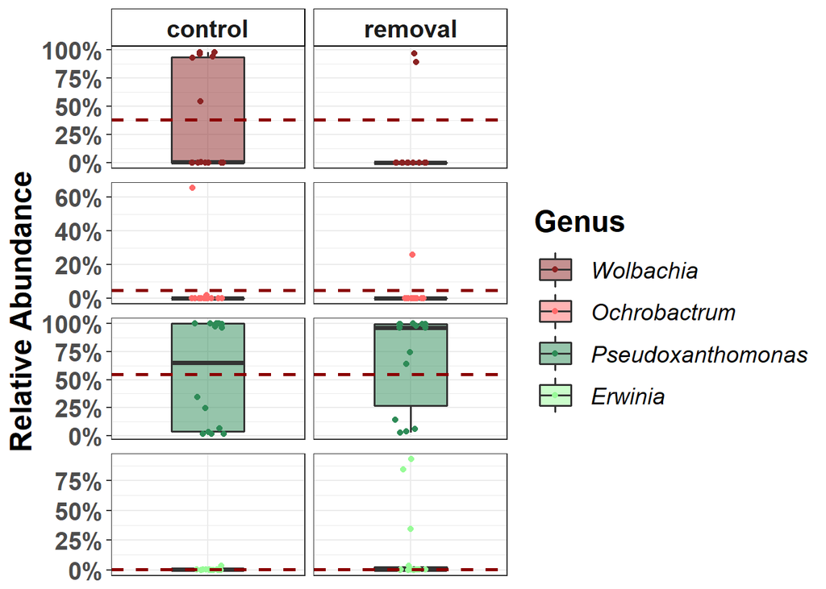

```r
p2<-ggplot(data = melt3, aes(x = Treatment, y = Abundance)) +
  geom_boxplot(aes(fill=Genus),alpha=0.5,lwd=0.7, position = position_dodge(width = 0.3), width=0.45,outlier.shape = NA) + geom_jitter(aes(color = Genus), height = 0, width = .1)+geom_hline(data= a_mean, aes(yintercept=mean_val), width=5,size=1,linetype="dashed", col = "darkred")+
  scale_fill_manual(values = colpal_bac, name = "Genus")+
  scale_color_manual(values = colpal_bac, name = "Genus")+
  labs(x = "", y = "Abundance\n")+
  facet_grid(Genus~fct_relevel(Treatment, "control", "removal"), scales = "free")+theme_bw()
p2<-p2+ theme(legend.position="right")+ylab("Relative Abundance")
p2<-p2+ theme(legend.text=element_text(size=14, face = "italic"))+
  theme(legend.key = element_rect(color = NA, fill = NA),legend.key.size = unit(0.9, "cm"))+
  theme(legend.title = element_text(size = 18, face = "bold"))+
  scale_y_continuous(labels=percent_format())
abu2<-p2 + theme(strip.background =element_rect(fill="white", color="black"))+
  theme(strip.text.x = element_text(size = 15, face = "bold"))
Treatment2<-abu2+theme(axis.title.y = element_text(size=18, face="bold"))+theme(axis.text.y = element_text(size=15, face="bold")) +
  theme(axis.text.x = element_text(size=18, angle=90,face="bold"))+
  theme(axis.title.x = element_blank(), axis.text.x=element_blank(),
        axis.ticks.x=element_blank())+
  theme(strip.text.y = element_blank())
relABcoreCR <- Treatment2 + theme(panel.spacing.y = unit(0.3, "cm"))

relABcoreCR
```

**plot core taxa of removal vs. 2<sup>nd</sup> attempt with relative abundance**

```r
Treats <- c('removal' = "removal", '2nd-foundation' = "2nd-att.")
ps4 <- prune_taxa(taxa_sums(rel.R2nd) > 0, rel.R2nd)
ps4 <- tax_glom(ps4, taxrank = 'Genus')
psOrd4 = subset_taxa(ps4, Genus=="Wolbachia" | Genus=="Pseudoxanthomonas" | Genus=="Ochrobactrum" | Genus=="Erwinia")
psctr = subset_samples(psOrd4, Treatment=="removal")
#Melt and plot
melt<-psmelt(psOrd4)
melt2<-psmelt(psctr)
melt$Treament <- factor(melt$Treatment, levels = c("removal", "2nd-foundation")) #, labels = c("removal", "2nd_found.")
melt$Genus <- factor(melt$Genus, levels = c("Wolbachia", "Ochrobactrum", "Pseudoxanthomonas", "Erwinia"))
melt2$Treament <- factor(melt2$Treatment, levels = c("removal", "2nd-foundation")) #, labels = c("removal", "2nd_found.")
melt2$Genus <- factor(melt2$Genus, levels = c("Wolbachia", "Ochrobactrum", "Pseudoxanthomonas", "Erwinia"))
a_mean <- melt2 %>%
  group_by(Genus) %>%
  summarize(mean_val = mean(Abundance))
print(a_mean)
```

```
## # A tibble: 4 x 2
##   Genus             mean_val
##   <fct>                <dbl>
## 1 Wolbachia           0.133
## 2 Ochrobactrum        0.0189
## 3 Pseudoxanthomonas   0.680
## 4 Erwinia             0.155
```

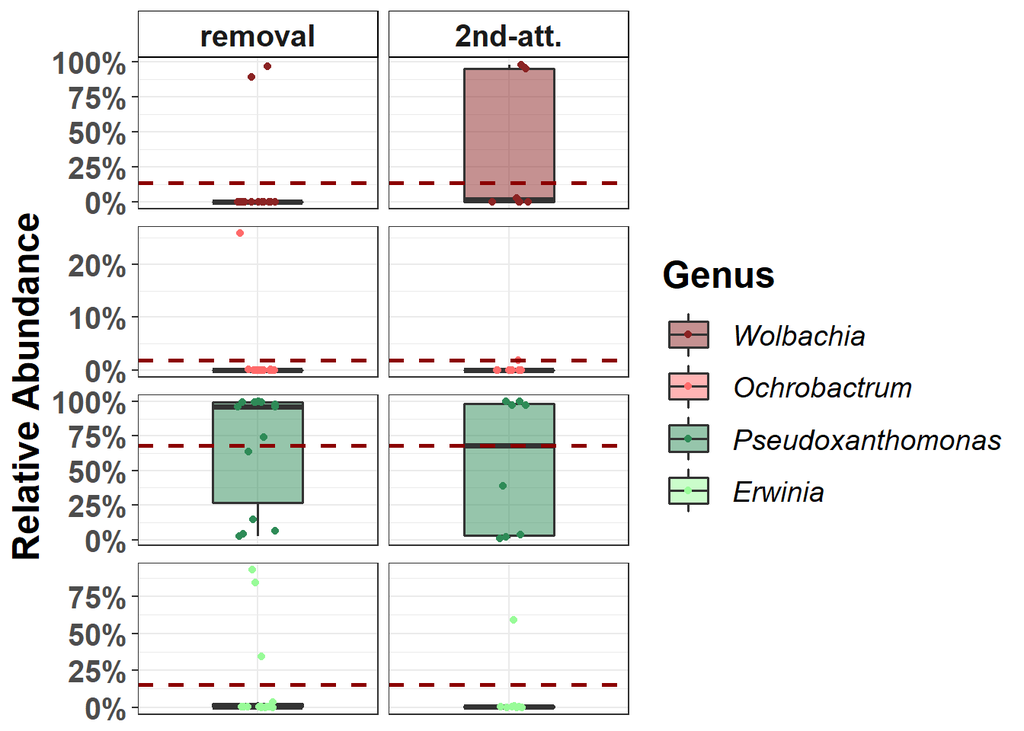

```r
p<-ggplot(data = melt, aes(x = Treatment, y = Abundance)) +
  geom_boxplot(aes(fill=Genus),alpha=0.5,lwd=0.7, position = position_dodge(width = 0.3), width=0.45,outlier.shape = NA) + geom_jitter(aes(color = Genus), height = 0, width = .1)+geom_hline(data= a_mean, aes(yintercept=mean_val), width=5,size=1,linetype="dashed", col = "darkred")+
  scale_fill_manual(values = colpal_bac, name = "Genus")+
  scale_color_manual(values = colpal_bac, name = "Genus")+
  labs(x = "", y = "Abundance\n")+
  facet_grid(Genus~fct_relevel(Treatment, "removal", "2nd-foundation"), labeller = as_labeller(Treats), scales = "free")+theme_bw()
p<-p+ theme(legend.position="right")+ylab("Relative Abundance")
p<-p+ theme(legend.text=element_text(size=14, face = "italic"))+theme(legend.key = element_rect(color = NA, fill = NA),legend.key.size = unit(0.9, "cm"))+theme(legend.title = element_text(size = 18, face = "bold"))+
  scale_y_continuous(labels=percent_format())
abu<-p + theme(strip.background =element_rect(fill="white", color="black"))+
  theme(strip.text.x = element_text(size = 15, face = "bold"))
TreatmentR2nd<-abu+theme(axis.title.y = element_text(size=18, face="bold"))+theme(axis.text.y = element_text(size=15, face="bold")) +
  theme(axis.text.x = element_text(size=18, angle=90,face="bold"))+
  theme(axis.title.x = element_blank(), axis.text.x=element_blank(),
        axis.ticks.x=element_blank())+
  theme(strip.text.y = element_blank())
relAbcoreR2nd_bac <- TreatmentR2nd + theme(panel.spacing.y = unit(0.3, "cm"))

relAbcoreR2nd_bac
```

### **Ordination analysis**

#### Sample ordination

##### **NMDS**

```r
set.seed(1)
ordi.CR = ordinate(rel.CR, "NMDS", "bray", k=3, trymax=100)
```

```
## *** Solution reached
```

```r
ordi.CR$stress
```

```
## [1] 0.004050816
```

```r
set.seed(1)
ordi.R2nd = ordinate(rel.R2nd, "NMDS", "bray", k=3, trymax=100)
```

```
## *** No convergence -- monoMDS stopping criteria:
##    100: no. of iterations >= maxit
```

```r
ordi.R2nd$stress
```

```
## [1] 0.000497131
```

plot NMDS

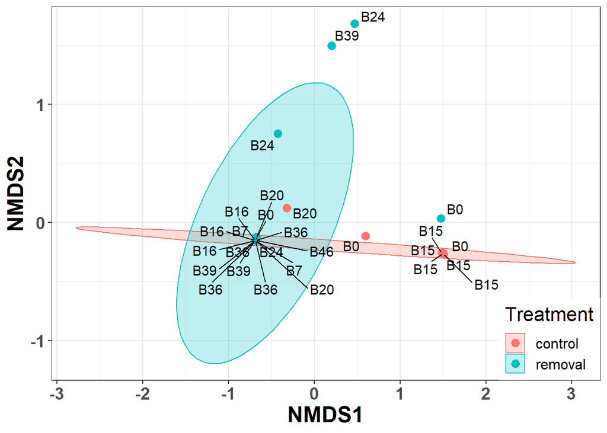

```r
NMDS_CR_bac <- plot_ordination(rel.CR, ordi.CR, color = "Treatment", axes=c(1,2))+
  stat_ellipse(level = 0.95, geom = "polygon", aes(fill = Treatment), alpha = 0.25)+
  geom_point(size=3, inherit.aes=T)+
  geom_text_repel(aes(label=Linage), color = "black", size = 4, max.overlaps = Inf)+
  theme_bw()+
  theme(legend.justification=c(1,0), legend.position=c(1,0))+
  theme(axis.text = element_text(size = 14, face = "bold"))+
  theme(axis.title = element_text(size = 18, face = "bold"))+
  theme(legend.text = element_text(size = 12))+
  theme(legend.title = element_text(size = 16))+
  theme(title = element_text(size = 18))

NMDS_CR_bac
```

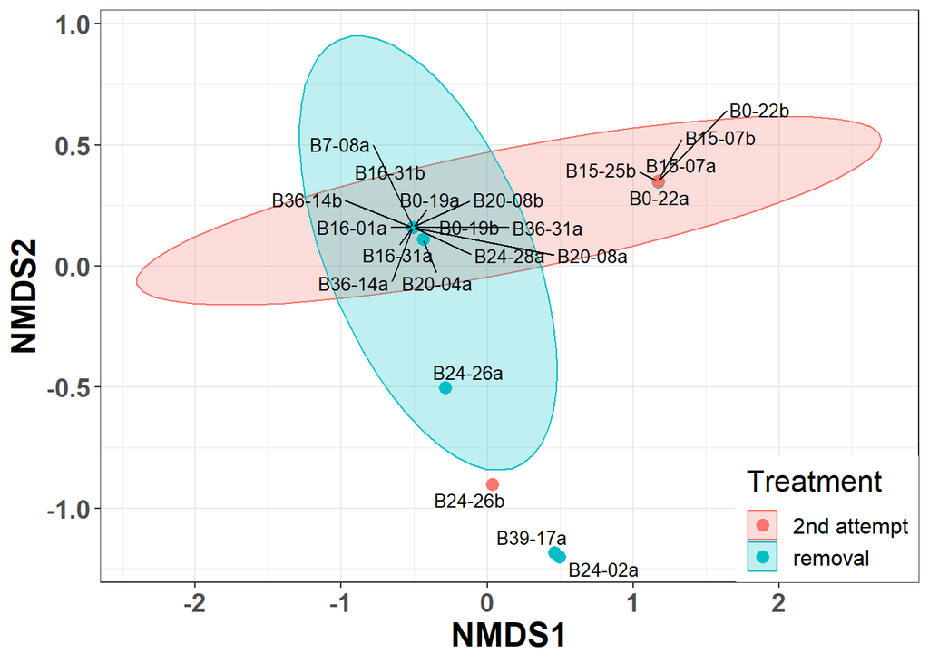

```r
sample_data(rel.R2nd)$Treatment <- as.factor(sample_data(rel.R2nd)$Treatment)
levels(sample_data(rel.R2nd)$Treatment) = c("2nd attempt", "removal")

NMDS_R2nd_bac <- plot_ordination(rel.R2nd, ordi.R2nd, color = "Treatment", axes=c(1,2))+
  stat_ellipse(level = 0.95, geom = "polygon", aes(fill = Treatment), alpha = 0.25)+
  geom_point(size=3, inherit.aes=T)+
  geom_text_repel(aes(label=Sample), color = "black", size = 3.5, max.overlaps = Inf)+
  theme_bw()+
  theme(legend.justification=c(1,0), legend.position=c(1,0))+
  theme(axis.text = element_text(size = 14, face = "bold"))+
  theme(axis.title = element_text(size = 18, face = "bold"))+
  theme(legend.text = element_text(size = 12))+
  theme(legend.title = element_text(size = 16))+
  theme(title = element_text(size = 18))

NMDS_R2nd_bac
```

### **Permanova** for community-level multivariate comparisons

PERMANOVA quantifies multivariate community-level differences between groups.

```r
# Pick relative abundances (compositional) and sample metadata
otu.CR <- abundances(rel.CR)
meta.CR <- meta(rel.CR)

otu.R2nd <- abundances(rel.R2nd)
meta.R2nd <- meta(rel.R2nd)
```

#### PERMANOVA significance test for group-level differences

Now let us evaluate whether the Treatment has a significant effect on overall garden microbiota composition. Perform PERMANOVA:

```r
# control vs. removal
set.seed(1)
adonis2(distance(rel.CR, method = "bray") ~ Treatment + Linage, data = meta.CR)
```

```
## Permutation test for adonis under reduced model
## Terms added sequentially (first to last)
## Permutation: free
## Number of permutations: 999
##
## adonis2(formula = distance(rel.CR, method = "bray") ~ Treatment + Linage, data = meta.CR)
##           Df SumOfSqs      R2      F Pr(>F)
## Treatment  1   0.4260 0.06554 4.2998  0.038 *
## Linage     8   4.2905 0.66007 5.4126  0.001 ***
## Residual  18   1.7835 0.27439
## Total     27   6.5001 1.00000
## ---
## Signif. codes:  0 '***' 0.001 '**' 0.01 '*' 0.05 '.' 0.1 ' ' 1
```

```r
#removal vs. 2^nd^ attempt
set.seed(1)
adonis2(distance(rel.R2nd, method = "bray") ~ Treatment + Linage, data = meta.R2nd)
```

```
## Permutation test for adonis under reduced model
## Terms added sequentially (first to last)
## Permutation: free
## Number of permutations: 999
##
## adonis2(formula = distance(rel.R2nd, method = "bray") ~ Treatment + Linage, data = meta.R2nd)
##           Df SumOfSqs      R2      F Pr(>F)
## Treatment  1   0.2100 0.04241 1.8759  0.169
## Linage     7   3.2869 0.66369 4.1939  0.003 **
## Residual  13   1.4555 0.29390
## Total     21   4.9525 1.00000
## ---
## Signif. codes:  0 '***' 0.001 '**' 0.01 '*' 0.05 '.' 0.1 ' ' 1
```

#### Checking the homogeneity condition

```r
# control vs. removal
dist <- vegdist(t(otu.CR))
dist.2 <- betadisper(dist, meta.CR$Linage)
anova(dist.2)
```

```
## Analysis of Variance Table
##
## Response: Distances
##           Df  Sum Sq  Mean Sq F value Pr(>F)
## Groups     8 0.60721 0.075901  1.1552  0.374
## Residuals 19 1.24843 0.065707
```

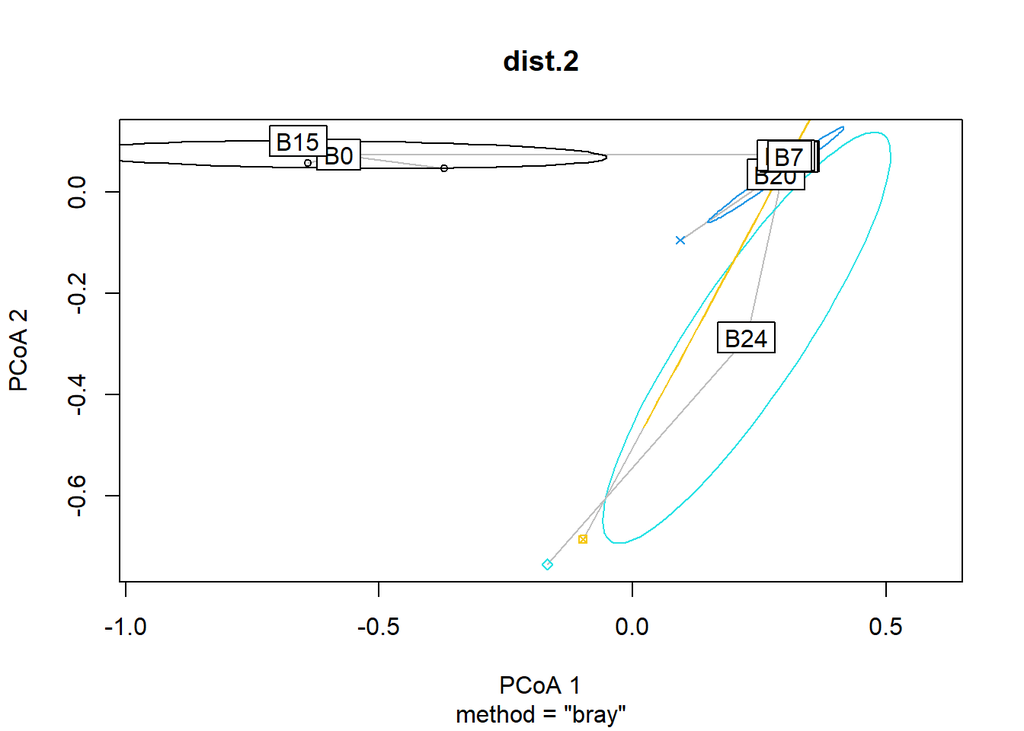

```r
plot(dist.2, hull = FALSE, ellipse = TRUE)
```

```r
# removal vs. 2^nd^ attempt
dist2 <- vegdist(t(otu.R2nd))
dist2.2 <- betadisper(dist2, meta.R2nd$Linage)
anova(dist2.2)
```

```
## Analysis of Variance Table
##
## Response: Distances
##           Df  Sum Sq  Mean Sq F value Pr(>F)
## Groups     7 0.76889 0.109841  2.1272 0.1087
## Residuals 14 0.72292 0.051637
```

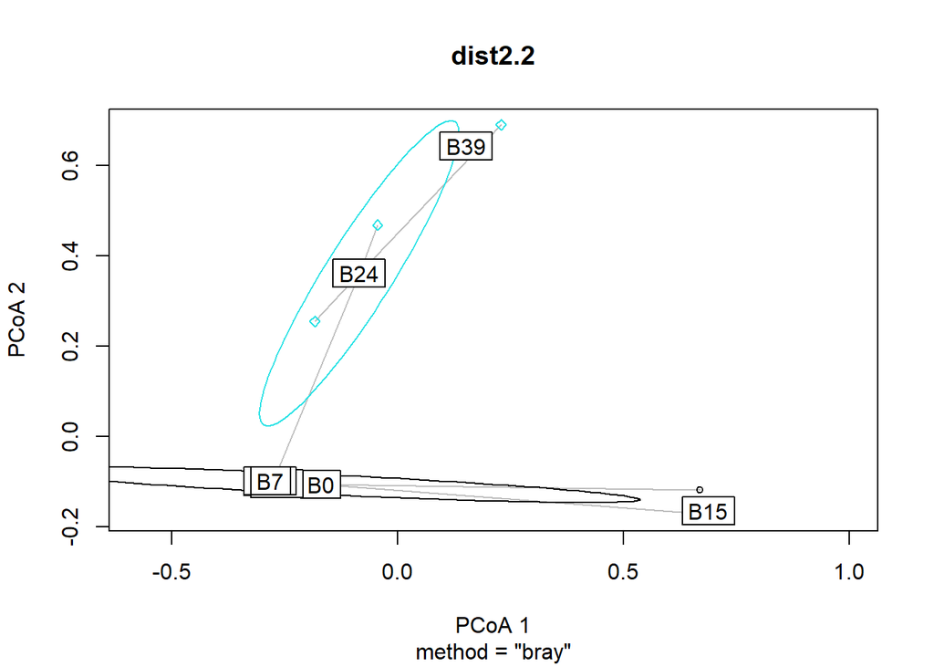

```r
plot(dist2.2, hull = FALSE, ellipse = TRUE)
```

## closer look at most abundant taxa

subset dataset Bacteria_Genus of both combinations to most abundant Geni (each *Wolbachia*, *Pseudoxanthomonas*) (high.reads with rel. abundance of total dataset)

```r
WolbachiaCR <- subset_taxa(rel.CR, Genus == "Wolbachia")
dfWCR <- WolbachiaCR %>%
  tax_glom(taxrank = "Genus") %>%
  psmelt()


PseudoCR <- subset_taxa(rel.CR, Genus == "Pseudoxanthomonas")
dfPCR <- PseudoCR %>%
  tax_glom(taxrank = "Genus") %>%
  psmelt()


WolbachiaR2nd <- subset_taxa(rel.R2nd, Genus == "Wolbachia")
dfWR2nd <- WolbachiaR2nd %>%
  tax_glom(taxrank = "Genus") %>%
  psmelt()


PseudoR2nd <- subset_taxa(rel.R2nd, Genus == "Pseudoxanthomonas")
dfPR2nd <- PseudoR2nd %>%
  tax_glom(taxrank = "Genus") %>%
  psmelt()
```

### dataset *Wolbachia*

abundance between treatments

Tukey transformation of data

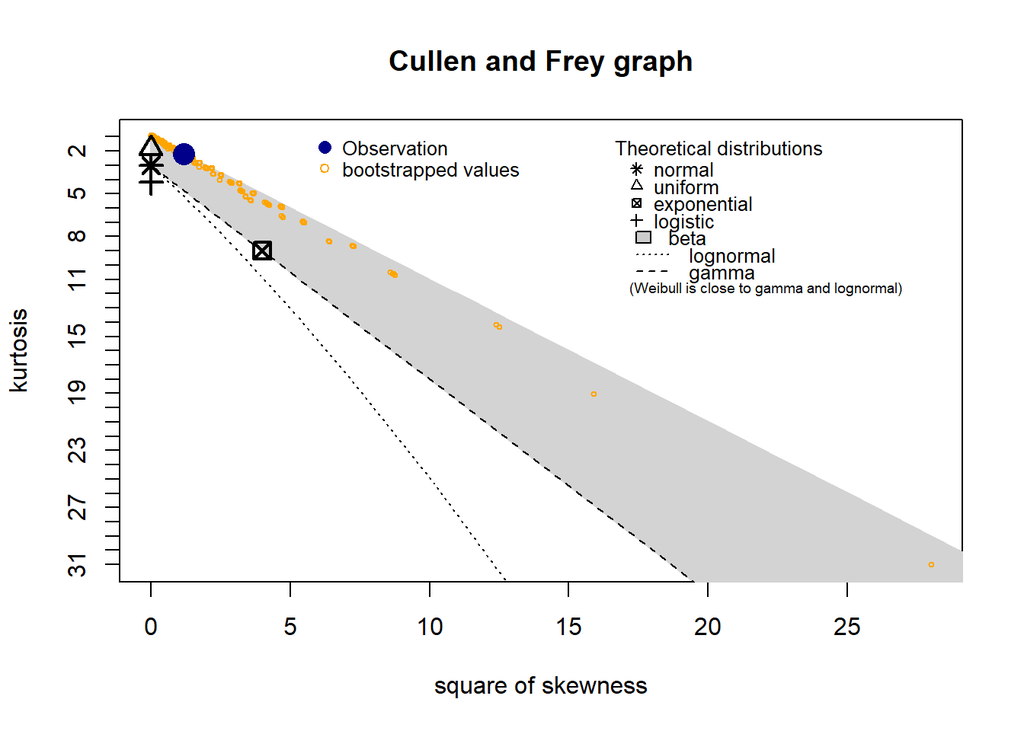

```
## summary statistics
## ------
## min:  0   max:  0.9822504
## median:  0.0001955422
## mean:  0.2575581
## estimated sd:  0.4204394
## estimated skewness:  1.088921
## estimated kurtosis:  2.194203
```

```r
descdist(dfWCR$Abundance, boot = 1000)
```

```r
library(rcompanion)

dfWCR$Ab.tuk <- rcompanion::transformTukey(dfWCR$Abundance)
```

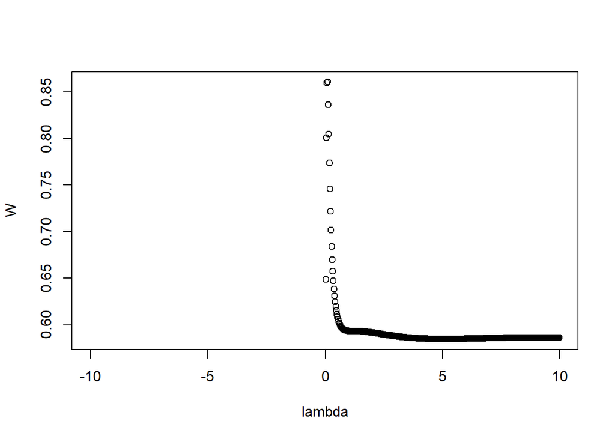

```
##
##     lambda      W Shapiro.p.value
## 405    0.1 0.8607        0.001548
##
## if (lambda >  0){TRANS = x ^ lambda}
## if (lambda == 0){TRANS = log(x)}
## if (lambda <  0){TRANS = -1 * x ^ lambda}
```

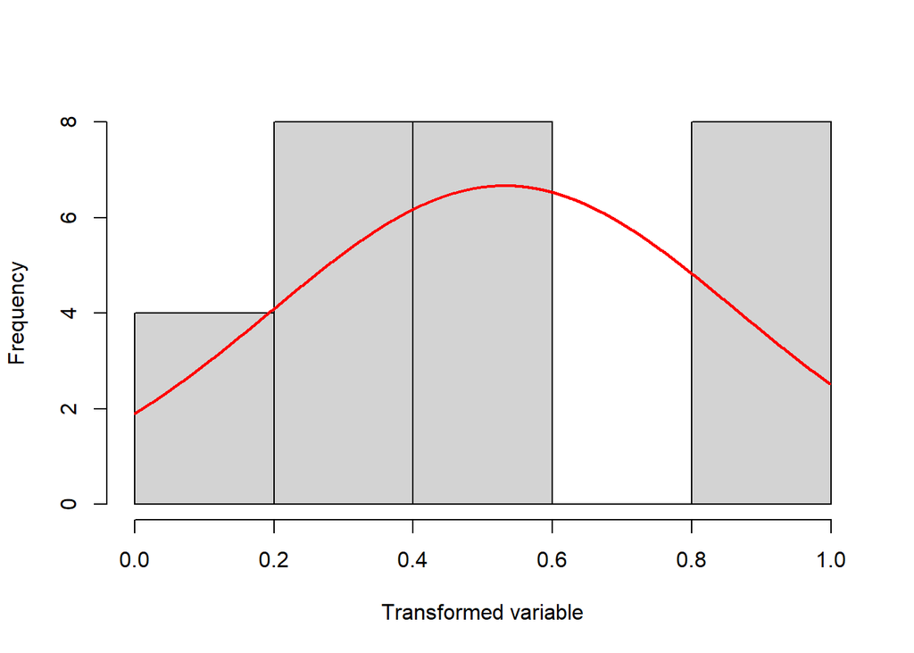

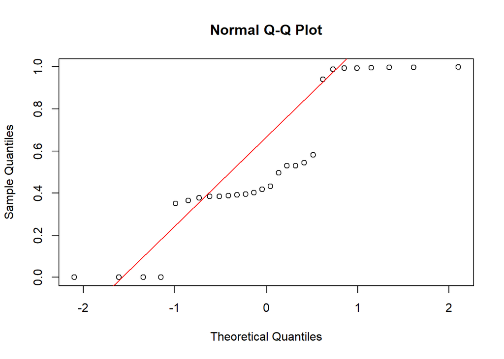

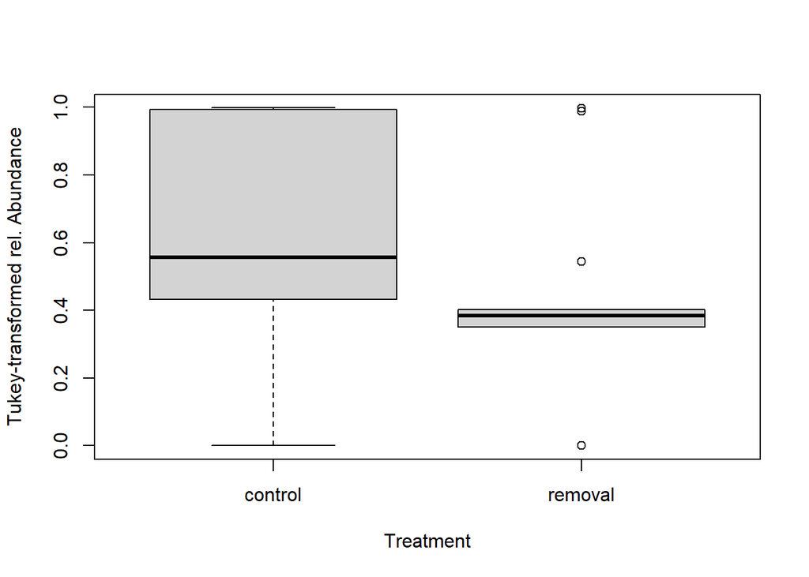

```r
boxplot(Ab.tuk ~ Treatment, data = dfWCR, ylab = "Tukey-transformed rel. Abundance", xlab = "Treatment")
```

```r
trans <- lm(Ab.tuk ~ Treatment + Linage, data = dfWCR)
Anova(trans, type="II")
```

```
## Anova Table (Type II tests)
##
## Response: Ab.tuk
##            Sum Sq Df F value    Pr(>F)
## Treatment 0.07815  1  2.4061 0.1382692
## Linage    1.95094  8  7.5085 0.0002021 ***
## Residuals 0.58462 18
## ---
## Signif. codes:  0 '***' 0.001 '**' 0.01 '*' 0.05 '.' 0.1 ' ' 1
```

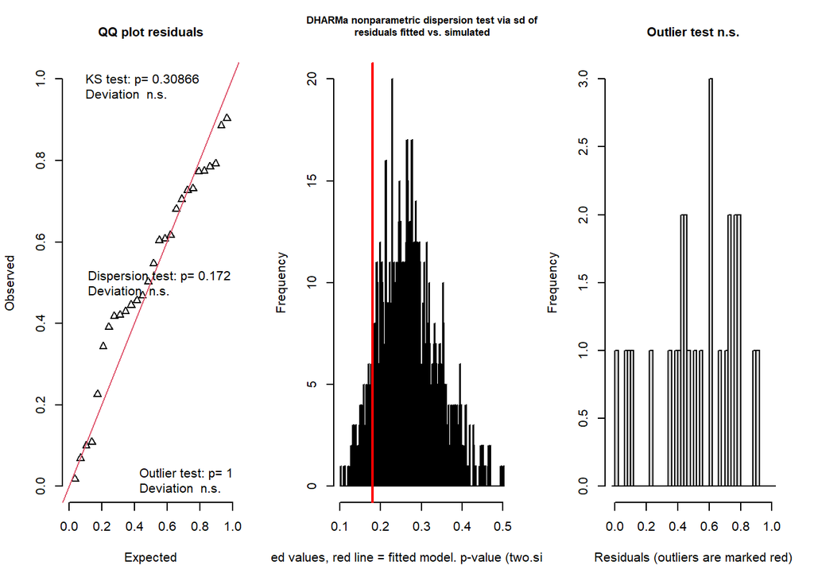

```
## $uniformity
##
##  One-sample Kolmogorov-Smirnov test
##
## data:  simulationOutput$scaledResiduals
## D = 0.17671, p-value = 0.3087
## alternative hypothesis: two-sided
##
##
## $dispersion
##
##  DHARMa nonparametric dispersion test via sd of residuals fitted vs.
##  simulated
##
## data:  simulationOutput
## dispersion = 0.66538, p-value = 0.172
## alternative hypothesis: two.sided
##
##
## $outliers
##
##  DHARMa outlier test based on exact binomial test with approximate
##  expectations
##
## data:  simulationOutput
## outliers at both margin(s) = 0, observations = 28, p-value = 1
## alternative hypothesis: true probability of success is not equal to 0.001998002
## 95 percent confidence interval:
##  0.0000000 0.1234361
## sample estimates:
## frequency of outliers (expected: 0.001998001998002 )
##                                                    0
```

```
## $uniformity
##
##  One-sample Kolmogorov-Smirnov test
##
## data:  simulationOutput$scaledResiduals
## D = 0.17671, p-value = 0.3087
## alternative hypothesis: two-sided
##
##
## $dispersion
##
##  DHARMa nonparametric dispersion test via sd of residuals fitted vs.
##  simulated
##
## data:  simulationOutput
## dispersion = 0.66538, p-value = 0.172
## alternative hypothesis: two.sided
##
##
## $outliers
##
##  DHARMa outlier test based on exact binomial test with approximate
##  expectations
##
## data:  simulationOutput
## outliers at both margin(s) = 0, observations = 28, p-value = 1
## alternative hypothesis: true probability of success is not equal to 0.001998002
## 95 percent confidence interval:
##  0.0000000 0.1234361
## sample estimates:
## frequency of outliers (expected: 0.001998001998002 )
##                                                    0
```

```r
res_trans <- simulateResiduals(trans, n = 1000)
testResiduals(res_trans)
```

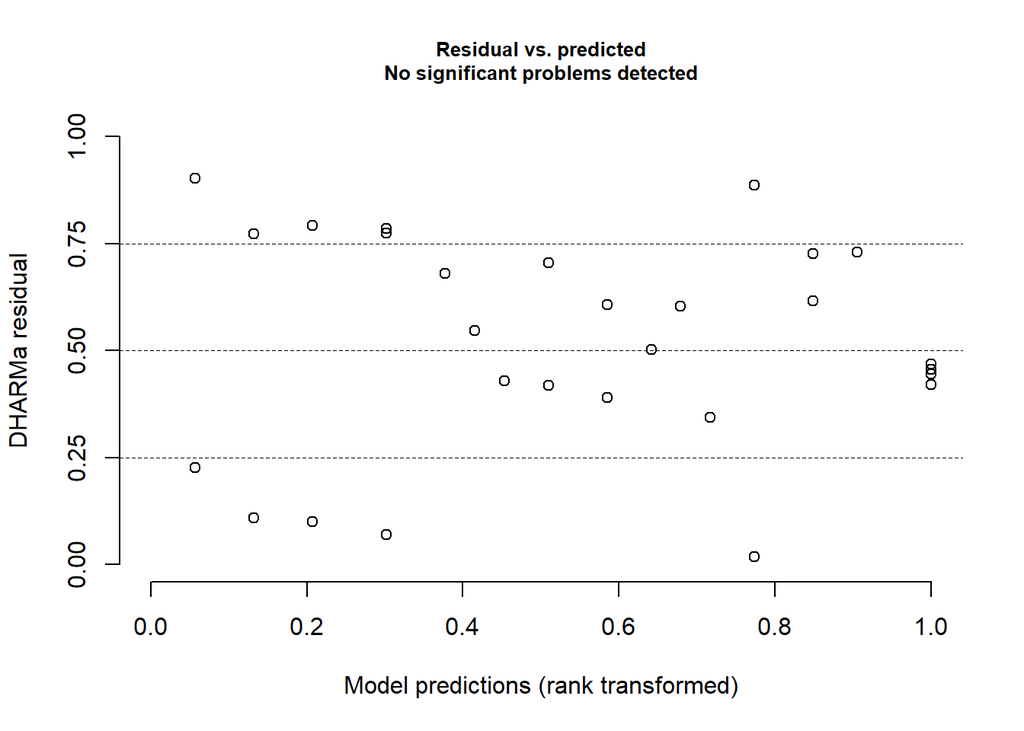

```r
plotResiduals(res_trans)
```

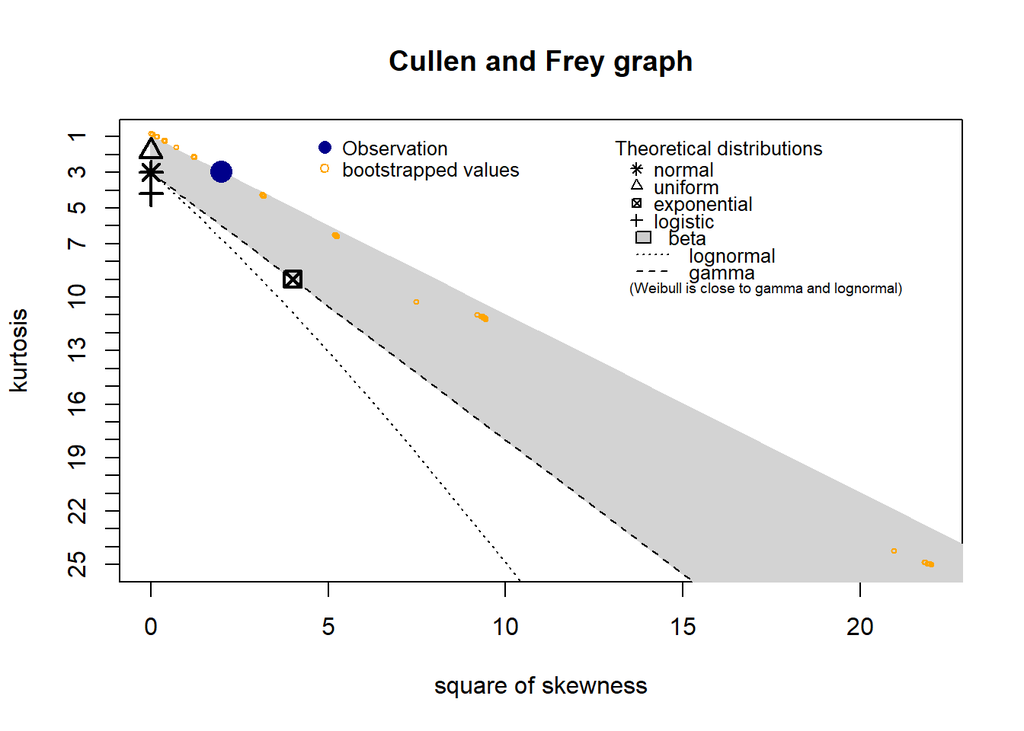

```
## summary statistics
## ------
## min:  0   max:  0.9793903
## median:  9.297361e-05
## mean:  0.2168947
## estimated sd:  0.406304
## estimated skewness:  1.403302
## estimated kurtosis:  2.967066
```

```r
descdist(dfWR2nd$Abundance, boot = 1000)
```

```r
dfWR2nd$Ab.tuk <- rcompanion::transformTukey(dfWR2nd$Abundance)
```

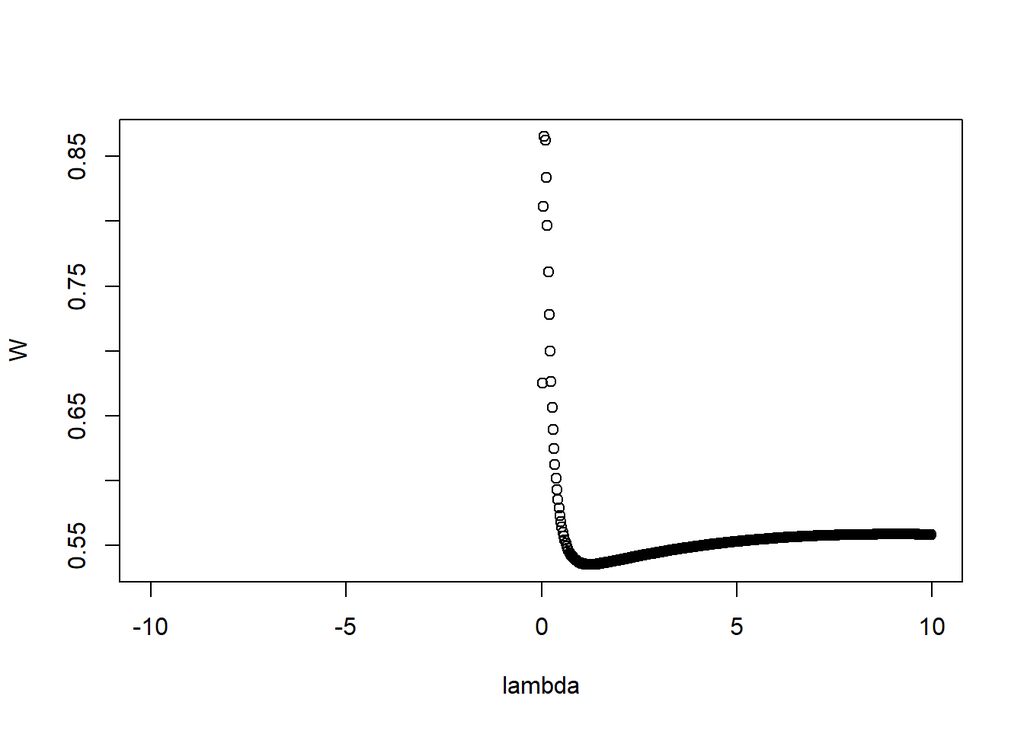

```
##
##     lambda      W Shapiro.p.value
## 404  0.075 0.8653        0.006398
##
## if (lambda >  0){TRANS = x ^ lambda}
## if (lambda == 0){TRANS = log(x)}
## if (lambda <  0){TRANS = -1 * x ^ lambda}
```

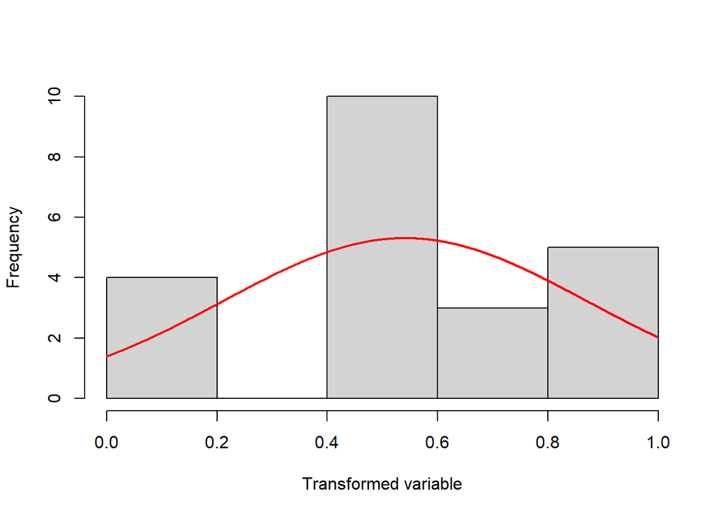

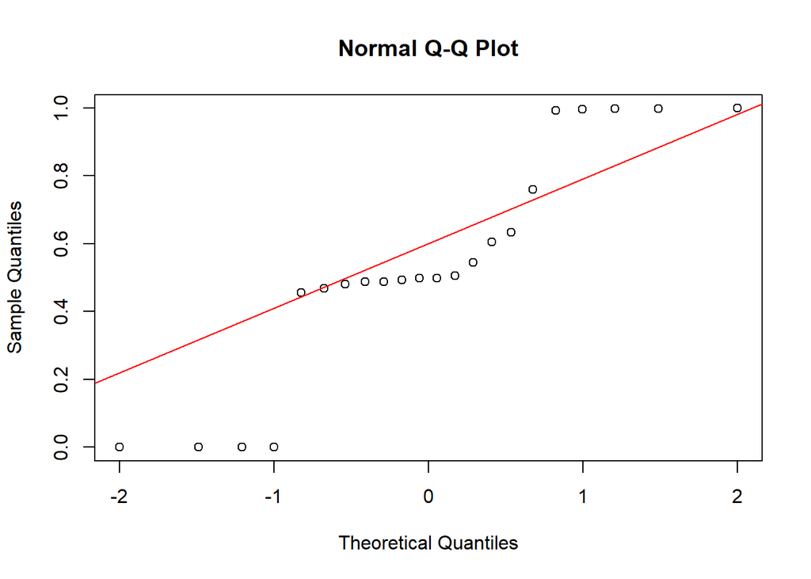

```r
trans <- lm(Ab.tuk ~ Treatment + Linage, data = dfWR2nd)
Anova(trans, type="II")
```

```
## Anova Table (Type II tests)
##
## Response: Ab.tuk
##            Sum Sq Df F value  Pr(>F)
## Treatment 0.02523  1  0.4089 0.53363
## Linage    1.26758  7  2.9349 0.04463 *
## Residuals 0.80210 13
## ---
## Signif. codes:  0 '***' 0.001 '**' 0.01 '*' 0.05 '.' 0.1 ' ' 1
```

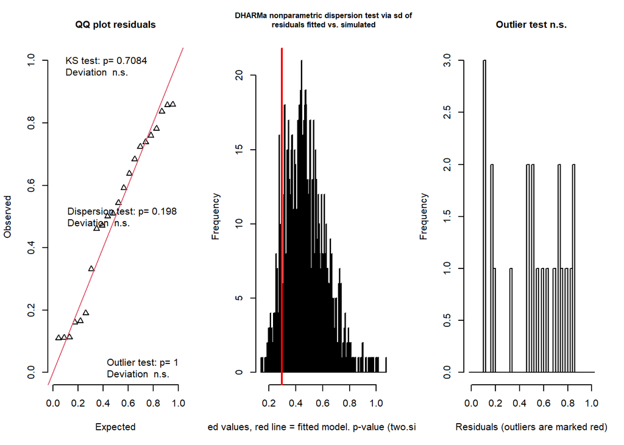

```
## $uniformity
##
##  One-sample Kolmogorov-Smirnov test
##
## data:  simulationOutput$scaledResiduals
## D = 0.14282, p-value = 0.7084
## alternative hypothesis: two-sided
##
##
## $dispersion
##
##  DHARMa nonparametric dispersion test via sd of residuals fitted vs.
##  simulated
##
## data:  simulationOutput
## dispersion = 0.61762, p-value = 0.198
## alternative hypothesis: two.sided
##
##
## $outliers
##
##  DHARMa outlier test based on exact binomial test with approximate
##  expectations
##
## data:  simulationOutput
## outliers at both margin(s) = 0, observations = 22, p-value = 1
## alternative hypothesis: true probability of success is not equal to 0.001998002
## 95 percent confidence interval:
##  0.0000000 0.1543725
## sample estimates:
## frequency of outliers (expected: 0.001998001998002 )
##                                                    0
```

```
## $uniformity
##
##  One-sample Kolmogorov-Smirnov test
##
## data:  simulationOutput$scaledResiduals
## D = 0.14282, p-value = 0.7084
## alternative hypothesis: two-sided
##
##
## $dispersion
##
##  DHARMa nonparametric dispersion test via sd of residuals fitted vs.
##  simulated
##
## data:  simulationOutput
## dispersion = 0.61762, p-value = 0.198
## alternative hypothesis: two.sided
##
##
## $outliers
##
##  DHARMa outlier test based on exact binomial test with approximate
##  expectations
##
## data:  simulationOutput
## outliers at both margin(s) = 0, observations = 22, p-value = 1
## alternative hypothesis: true probability of success is not equal to 0.001998002
## 95 percent confidence interval:
##  0.0000000 0.1543725
## sample estimates:
## frequency of outliers (expected: 0.001998001998002 )
##                                                    0
```

```r
res_trans <- simulateResiduals(trans, n = 1000)
testResiduals(res_trans)
```

### dataset *Pseudoxanthomonas*

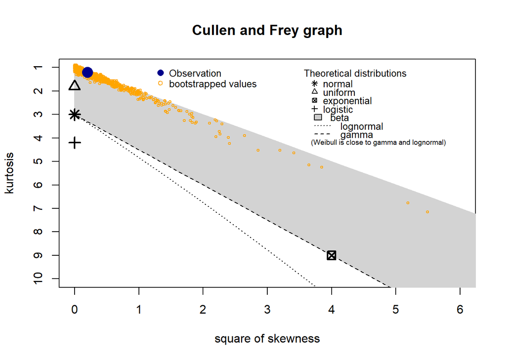

```
## summary statistics
## ------
## min:  0.01552795   max:  0.9994271
## median:  0.9602095
## mean:  0.613549
## estimated sd:  0.4394213
## estimated skewness:  -0.4451336
## estimated kurtosis:  1.207382
```

```r
descdist(dfPCR$Abundance, boot = 1000)
```

```r
logistic <- function(p) log(p / (1-p) +0.01)

dfPCR.mod <- lm(logistic(Abundance) ~ Treatment + Linage, data = dfPCR)
Anova(dfPCR.mod, type = "II")
```

```
## Anova Table (Type II tests)
##
## Response: logistic(Abundance)
##            Sum Sq Df F value    Pr(>F)
## Treatment   1.116  1  0.1770 0.6789498
## Linage    299.461  8  5.9393 0.0008398 ***
## Residuals 113.445 18
## ---
## Signif. codes:  0 '***' 0.001 '**' 0.01 '*' 0.05 '.' 0.1 ' ' 1
```

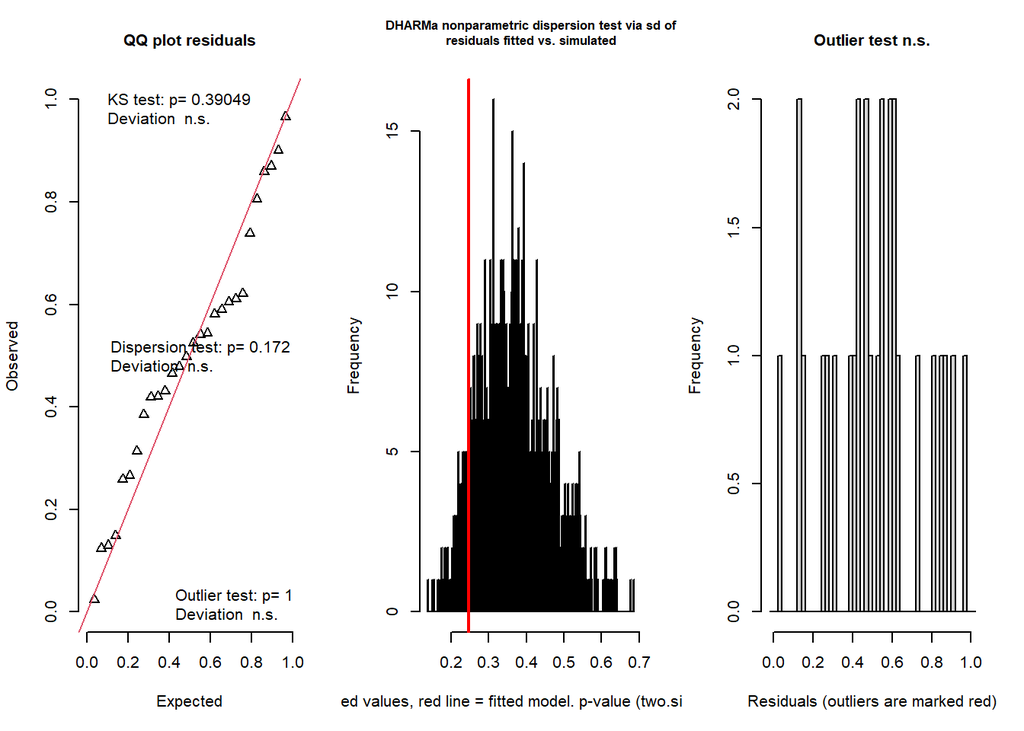

```
## $uniformity
##
##  One-sample Kolmogorov-Smirnov test
##
## data:  simulationOutput$scaledResiduals
## D = 0.16471, p-value = 0.3905
## alternative hypothesis: two-sided
##
##
## $dispersion
##
##  DHARMa nonparametric dispersion test via sd of residuals fitted vs.
##  simulated
##
## data:  simulationOutput
## dispersion = 0.66538, p-value = 0.172
## alternative hypothesis: two.sided
##
##
## $outliers
##
##  DHARMa outlier test based on exact binomial test with approximate
##  expectations
##
## data:  simulationOutput
## outliers at both margin(s) = 0, observations = 28, p-value = 1
## alternative hypothesis: true probability of success is not equal to 0.001998002
## 95 percent confidence interval:
##  0.0000000 0.1234361
## sample estimates:
## frequency of outliers (expected: 0.001998001998002 )
##                                                    0
```

```
## $uniformity
##
##  One-sample Kolmogorov-Smirnov test
##
## data:  simulationOutput$scaledResiduals
## D = 0.16471, p-value = 0.3905
## alternative hypothesis: two-sided
##
##
## $dispersion
##
##  DHARMa nonparametric dispersion test via sd of residuals fitted vs.
##  simulated
##
## data:  simulationOutput
## dispersion = 0.66538, p-value = 0.172
## alternative hypothesis: two.sided
##
##
## $outliers
##
##  DHARMa outlier test based on exact binomial test with approximate
##  expectations
##
## data:  simulationOutput
## outliers at both margin(s) = 0, observations = 28, p-value = 1
## alternative hypothesis: true probability of success is not equal to 0.001998002
## 95 percent confidence interval:
##  0.0000000 0.1234361
## sample estimates:
## frequency of outliers (expected: 0.001998001998002 )
##                                                    0
```

```r
res_dfPCR.mod <- simulateResiduals(dfPCR.mod, n = 1000)
testResiduals(res_dfPCR.mod)
```

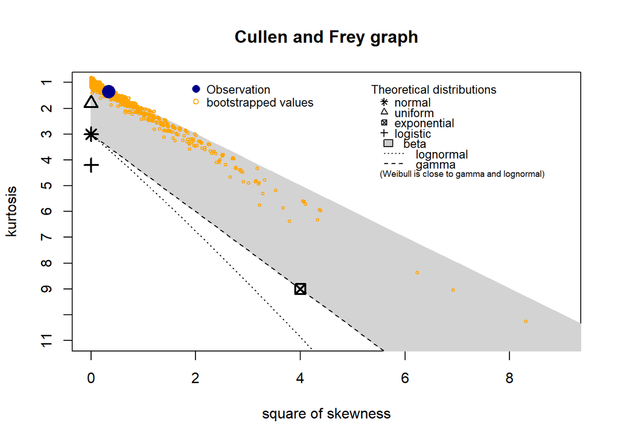

```
## summary statistics
## ------
## min:  0.006869901   max:  0.9993608
## median:  0.9616264
## mean:  0.6327369
## estimated sd:  0.4342354
## estimated skewness:  -0.5796202
## estimated kurtosis:  1.353467
```

```r
descdist(dfPR2nd$Abundance, boot = 1000)
```

```r
dfPR2nd.mod <- lm(logistic(Abundance) ~ Treatment + Linage, data = dfPR2nd)
Anova(dfPR2nd.mod, type = "II")
```

```
## Anova Table (Type II tests)
##
## Response: logistic(Abundance)
##            Sum Sq Df F value   Pr(>F)
## Treatment   0.996  1  0.1634 0.692660
## Linage    228.179  7  5.3447 0.004643 **
## Residuals  79.286 13
## ---
## Signif. codes:  0 '***' 0.001 '**' 0.01 '*' 0.05 '.' 0.1 ' ' 1
```

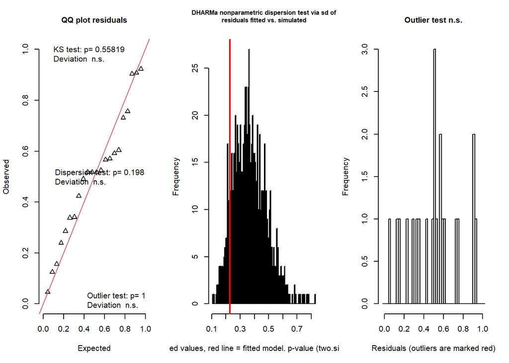

```
## $uniformity
##
##  One-sample Kolmogorov-Smirnov test
##
## data:  simulationOutput$scaledResiduals
## D = 0.16873, p-value = 0.5582
## alternative hypothesis: two-sided
##
##
## $dispersion
##
##  DHARMa nonparametric dispersion test via sd of residuals fitted vs.
##  simulated
##
## data:  simulationOutput
## dispersion = 0.61762, p-value = 0.198
## alternative hypothesis: two.sided
##
##
## $outliers
##
##  DHARMa outlier test based on exact binomial test with approximate
##  expectations
##
## data:  simulationOutput
## outliers at both margin(s) = 0, observations = 22, p-value = 1
## alternative hypothesis: true probability of success is not equal to 0.001998002
## 95 percent confidence interval:
##  0.0000000 0.1543725
## sample estimates:
## frequency of outliers (expected: 0.001998001998002 )
##                                                    0
```

```
## $uniformity
##
##  One-sample Kolmogorov-Smirnov test
##
## data:  simulationOutput$scaledResiduals
## D = 0.16873, p-value = 0.5582
## alternative hypothesis: two-sided
##
##
## $dispersion
##
##  DHARMa nonparametric dispersion test via sd of residuals fitted vs.
##  simulated
##
## data:  simulationOutput
## dispersion = 0.61762, p-value = 0.198
## alternative hypothesis: two.sided
##
##
## $outliers
##
##  DHARMa outlier test based on exact binomial test with approximate
##  expectations
##
## data:  simulationOutput
## outliers at both margin(s) = 0, observations = 22, p-value = 1
## alternative hypothesis: true probability of success is not equal to 0.001998002
## 95 percent confidence interval:
##  0.0000000 0.1543725
## sample estimates:
## frequency of outliers (expected: 0.001998001998002 )
##                                                    0
```

```r
res_dfPR2nd.mod <- simulateResiduals(dfPR2nd.mod, n = 1000)
testResiduals(res_dfPR2nd.mod)
```

## testing difference of ‘successfull’ vs. ‘failed’ nests

create subset of samples from ‘removal’ group

```r
REM <- subset_samples(rel.R2nd, Treatment == "removal")
REM <- prune_taxa(taxa_sums(REM) > 0, REM)

sample_data(REM)
```

```
##          Sample   Nest Linage Treatment age_sampling_d    Group
## B0-19a   B0-19a  B0-19     B0   removal             31 Bacteria
## B0-22a   B0-22a  B0-22     B0   removal             31 Bacteria
## B15-07a B15-07a B15-07    B15   removal             29 Bacteria
## B16-01a B16-01a B16-01    B16   removal             32 Bacteria
## B16-31a B16-31a B16-31    B16   removal             30 Bacteria
## B20-04a B20-04a B20-04    B20   removal             35 Bacteria
## B20-08a B20-08a B20-08    B20   removal             31 Bacteria
## B24-02a B24-02a B24-02    B24   removal             32 Bacteria
## B24-26a B24-26a B24-26    B24   removal             32 Bacteria
## B24-28a B24-28a B24-28    B24   removal             32 Bacteria
## B36-14a B36-14a B36-14    B36   removal             19 Bacteria
## B36-31a B36-31a B36-31    B36   removal             32 Bacteria
## B39-17a B39-17a B39-17    B39   removal             31 Bacteria
## B7-08a   B7-08a  B7-08     B7   removal             33 Bacteria
```

```r
suc = c("successfull", "successfull", "successfull", "failed", "successfull", "failed", "successfull", "failed", "successfull", "failed", "successfull", "failed", "failed", "failed")
sample_data(REM)$success <- suc

dfREM <- REM %>%
  tax_glom(taxrank = "Genus") %>%
  psmelt()
```

#### Permanova on data REM

```r
otu.REM <- abundances(REM)
meta.REM <- meta(REM)

set.seed(1)
adonis2(distance(REM, method = "bray") ~ success, data = meta.REM)
```

```
## Permutation test for adonis under reduced model
## Terms added sequentially (first to last)
## Permutation: free
## Number of permutations: 999
##
## adonis2(formula = distance(REM, method = "bray") ~ success, data = meta.REM)
##          Df SumOfSqs      R2      F Pr(>F)
## success   1  0.19689 0.07083 0.9147  0.573
## Residual 12  2.58296 0.92917
## Total    13  2.77985 1.00000
```

```r
dist <- vegdist(t(otu.REM))
dist.2 <- betadisper(dist, meta.REM$success)
anova(dist.2)
```

```
## Analysis of Variance Table
##
## Response: Distances
##           Df  Sum Sq  Mean Sq F value Pr(>F)
## Groups     1 0.00368 0.003684  0.0205 0.8885
## Residuals 12 2.15427 0.179522
```

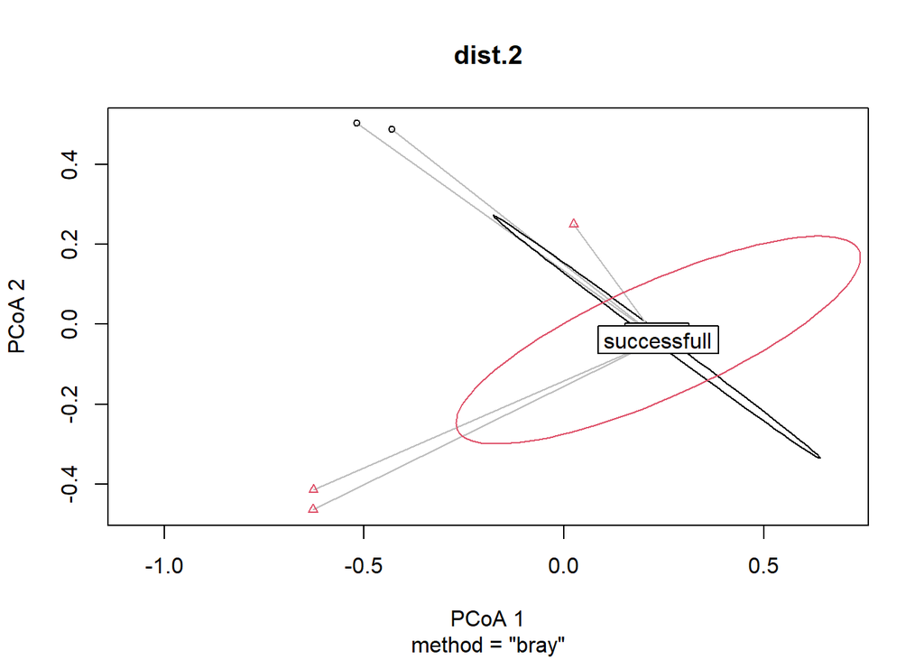

```r
plot(dist.2, hull = FALSE, ellipse = TRUE)
```

prepare data and plot

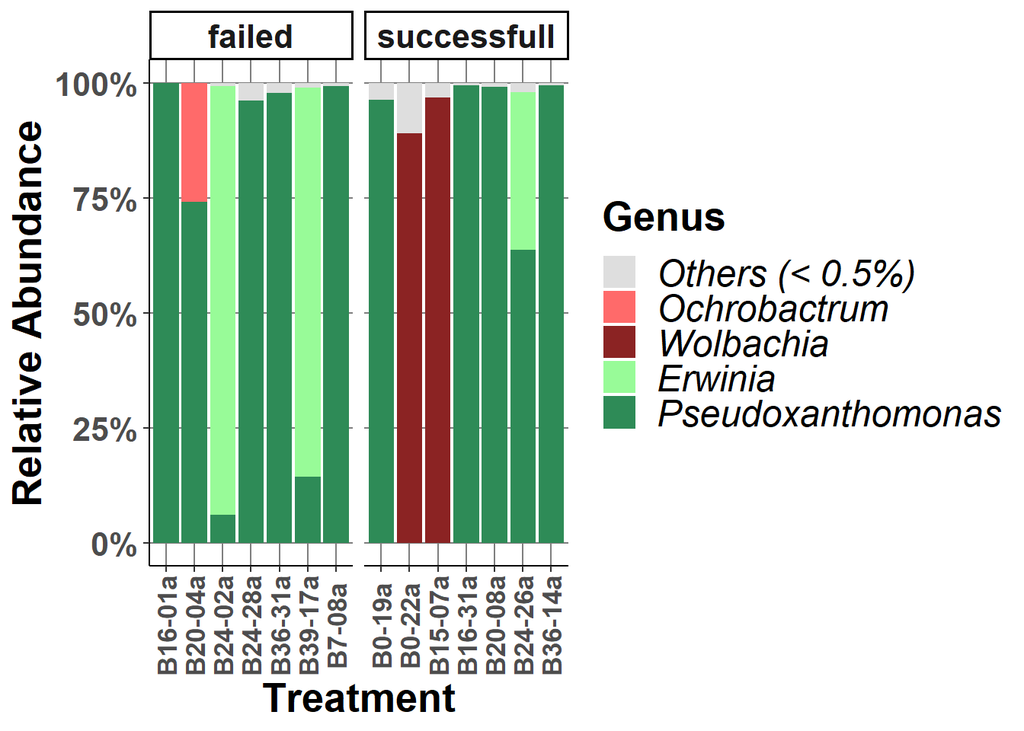

```r
REM.plot <- dfREM
REM.plot$Success <- factor(REM.plot$success, levels = c("successfull", "failed"))
REM.plot$Genus<-as.character(REM.plot$Genus)
REM.plot$Genus[REM.plot$Abundance<0.05]<-"Others"
REM.plot$Genus<-factor(REM.plot$Genus, levels = c("Others", "Ochrobactrum", "Wolbachia", "Erwinia","Pseudoxanthomonas"), labels = c("Others (< 0.5%)", "Ochrobactrum", "Wolbachia", "Erwinia","Pseudoxanthomonas"))


Fungi_Success_plot <-ggplot(REM.plot, aes(x = Sample, y = Abundance, fill = Genus)) +
  geom_bar(stat = "identity", color = NA,  position="fill") +
  scale_fill_manual(values = Plot_colors_g2, name = "Genus") +
  facet_grid(~success, scales = "free_x", space = "free_x")

FS<-Fungi_Success_plot +
  theme(plot.title = element_text(size = 20, face = "bold")) +
  theme_classic()+           #gets rid of background
  theme(panel.grid.major = element_line(colour = "grey50"))+
  labs(x="Treatment", y="Relative Abundance")+
  scale_y_continuous(labels=percent_format())+
  theme(axis.text.x=element_text(size = 13, angle = 90, vjust = 0.5))+
  theme(text = element_text(size=20, face = "bold"))+
  theme(legend.title = element_text(size = 20), legend.text = element_text(size = 18))+
  theme(legend.text = element_text(face = "italic"))

FS
```

#### plot core taxa of successfull vs. failed nests with relative abundance

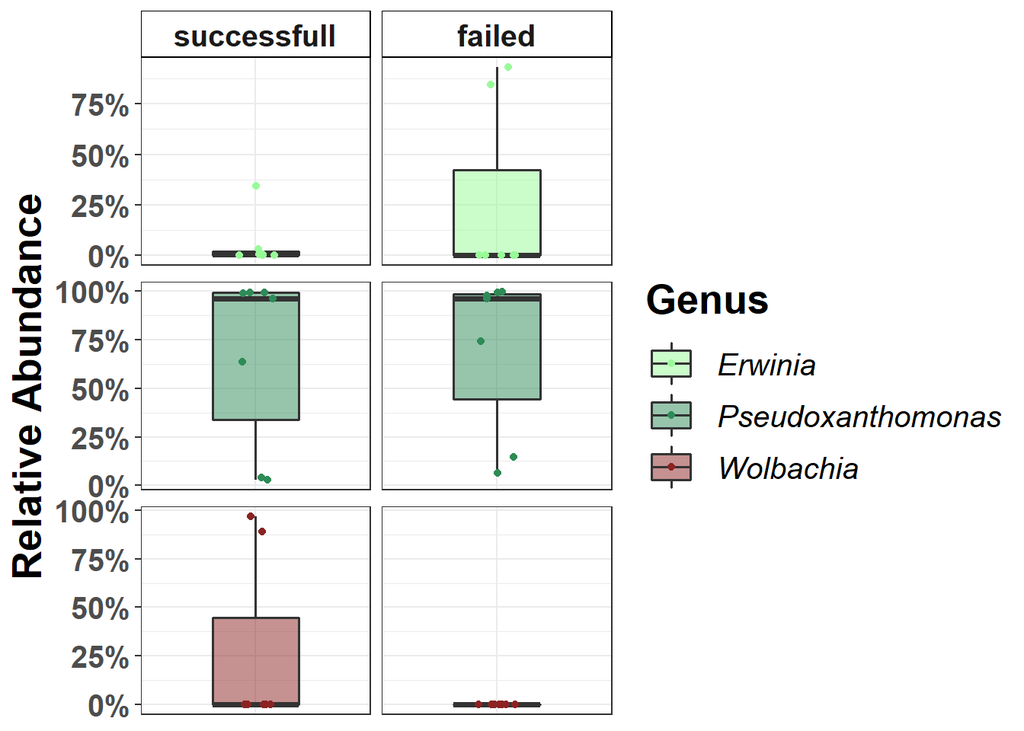

```r
dfREM.sub <- subset(dfREM, Genus == "Wolbachia" | Genus == "Pseudoxanthomonas" | Genus == "Erwinia")
ptax_col <- c("palegreen", "seagreen", "brown4")
ptax<-ggplot(data = dfREM.sub, aes(x = success, y = Abundance)) +
  geom_boxplot(aes(fill=Genus),alpha=0.5,lwd=0.7, position = position_dodge(width = 0.3), width=0.45,outlier.shape = NA) + geom_jitter(aes(color = Genus), height = 0, width = .1)+
  scale_fill_manual(values = ptax_col, name = "Genus")+
  scale_color_manual(values = ptax_col, name = "Genus")+
  labs(x = "", y = "Abundance\n")+
  facet_grid(Genus~fct_relevel(success, "successfull", "failed"), scales = "free")+theme_bw()
ptax<-ptax+ theme(legend.position="right")+ylab("Relative Abundance")
ptax<-ptax+ theme(legend.text=element_text(size=15, face = "italic"))+
  theme(legend.key = element_rect(color = NA, fill = NA),legend.key.size = unit(0.9, "cm"))+
  theme(legend.title = element_text(size = 20, face = "bold"))+
  scale_y_continuous(labels=percent_format())
abu2<-ptax + theme(strip.background =element_rect(fill="white", color="black"))+
  theme(strip.text.x = element_text(size = 15, face = "bold"))
Success.plot<-abu2+theme(axis.title.y = element_text(size=20, face="bold"))+theme(axis.text.y = element_text(size=15, face="bold")) +
  theme(axis.text.x = element_text(size=20, angle=90,face="bold"))+
  theme(axis.title.x = element_blank(), axis.text.x=element_blank(),
        axis.ticks.x=element_blank())+
  theme(strip.text.y = element_blank())
Success.plot_bac <- Success.plot + theme(panel.spacing.y = unit(0.3, "cm"))

Success.plot_bac
```

#### test if taxa are different in these two groups

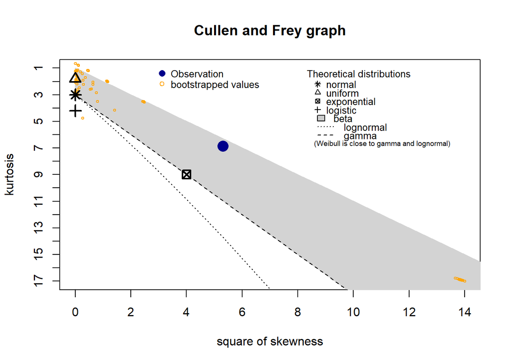

```
## summary statistics
## ------
## min:  0   max:  0.9685696
## median:  6.920423e-05
## mean:  0.1330016
## estimated sd:  0.337838
## estimated skewness:  2.304651
## estimated kurtosis:  6.869043
```

```r
Wrem <- subset(dfREM, Genus == "Wolbachia")
descdist(Wrem$Abundance, boot = 1000)
```

```r
Wrem.mod <- lm(logistic(Abundance) ~ success, data = Wrem)
Anova(Wrem.mod, type = "II")
```

```
## Anova Table (Type II tests)
##
## Response: logistic(Abundance)
##           Sum Sq Df F value Pr(>F)
## success   15.912  1  2.4623 0.1426
## Residuals 77.548 12
```

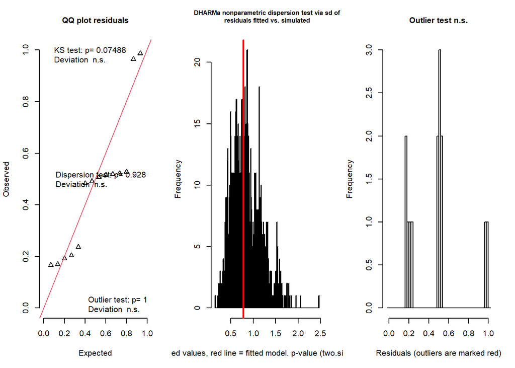

```
## $uniformity
##
##  One-sample Kolmogorov-Smirnov test
##
## data:  simulationOutput$scaledResiduals
## D = 0.32914, p-value = 0.07488
## alternative hypothesis: two-sided
##
##
## $dispersion
##
##  DHARMa nonparametric dispersion test via sd of residuals fitted vs.
##  simulated
##
## data:  simulationOutput
## dispersion = 0.92226, p-value = 0.928
## alternative hypothesis: two.sided
##
##
## $outliers
##
##  DHARMa outlier test based on exact binomial test with approximate
##  expectations
##
## data:  simulationOutput
## outliers at both margin(s) = 0, observations = 14, p-value = 1
## alternative hypothesis: true probability of success is not equal to 0.001998002
## 95 percent confidence interval:
##  0.0000000 0.2316358
## sample estimates:
## frequency of outliers (expected: 0.001998001998002 )
##                                                    0
```

```
## $uniformity
##
##  One-sample Kolmogorov-Smirnov test
##
## data:  simulationOutput$scaledResiduals
## D = 0.32914, p-value = 0.07488
## alternative hypothesis: two-sided
##
##
## $dispersion
##
##  DHARMa nonparametric dispersion test via sd of residuals fitted vs.
##  simulated
##
## data:  simulationOutput
## dispersion = 0.92226, p-value = 0.928
## alternative hypothesis: two.sided
##
##
## $outliers
##
##  DHARMa outlier test based on exact binomial test with approximate
##  expectations
##
## data:  simulationOutput
## outliers at both margin(s) = 0, observations = 14, p-value = 1
## alternative hypothesis: true probability of success is not equal to 0.001998002
## 95 percent confidence interval:
##  0.0000000 0.2316358
## sample estimates:
## frequency of outliers (expected: 0.001998001998002 )
##                                                    0
```

```r
res_Wrem.mod <- simulateResiduals(Wrem.mod, n = 1000)
testResiduals(res_Wrem.mod)
```

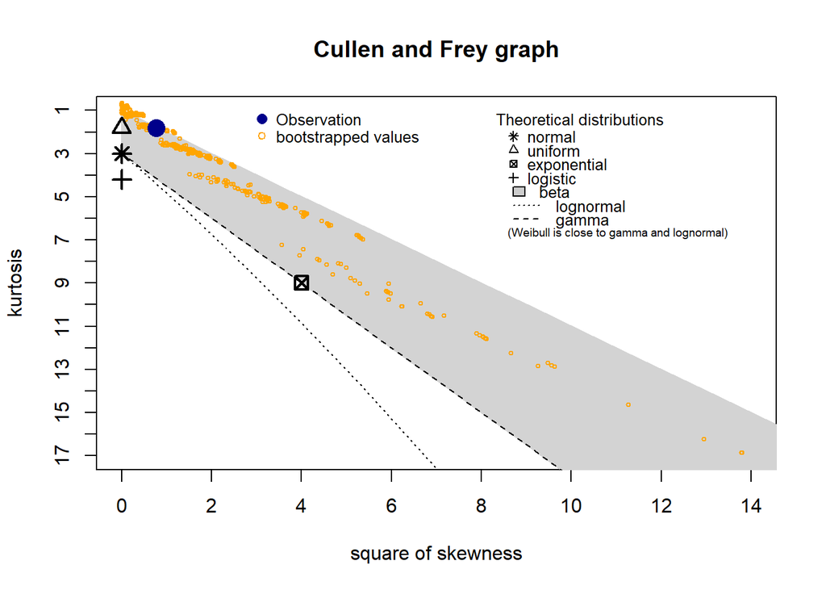

```
## summary statistics
## ------
## min:  0.02758178   max:  0.9987783
## median:  0.9616264
## mean:  0.680395
## estimated sd:  0.4157842
## estimated skewness:  -0.8779036
## estimated kurtosis:  1.800568
```

```r
Prem <- subset(dfREM, Genus == "Pseudoxanthomonas")
descdist(Prem$Abundance, boot = 1000)
```

```r
Prem.mod <- lm(logistic(Abundance) ~ success, data = Prem)
Anova(Prem.mod, type = "II")
```

```
## Anova Table (Type II tests)
##
## Response: logistic(Abundance)
##            Sum Sq Df F value Pr(>F)
## success     0.562  1  0.0441 0.8371
## Residuals 152.746 12
```

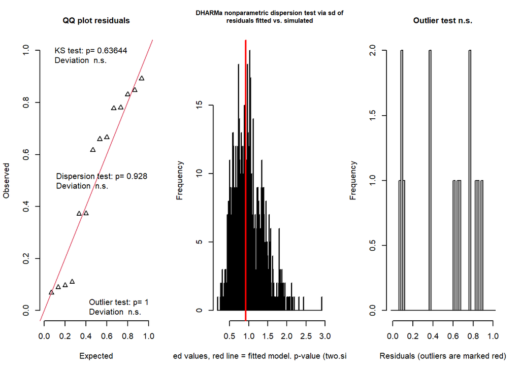

```
## $uniformity
##
##  One-sample Kolmogorov-Smirnov test
##
## data:  simulationOutput$scaledResiduals
## D = 0.18843, p-value = 0.6364
## alternative hypothesis: two-sided
##
##
## $dispersion
##
##  DHARMa nonparametric dispersion test via sd of residuals fitted vs.
##  simulated
##
## data:  simulationOutput
## dispersion = 0.92226, p-value = 0.928
## alternative hypothesis: two.sided
##
##
## $outliers
##
##  DHARMa outlier test based on exact binomial test with approximate
##  expectations
##
## data:  simulationOutput
## outliers at both margin(s) = 0, observations = 14, p-value = 1
## alternative hypothesis: true probability of success is not equal to 0.001998002
## 95 percent confidence interval:
##  0.0000000 0.2316358
## sample estimates:
## frequency of outliers (expected: 0.001998001998002 )
##                                                    0
```

```
## $uniformity
##
##  One-sample Kolmogorov-Smirnov test
##
## data:  simulationOutput$scaledResiduals
## D = 0.18843, p-value = 0.6364
## alternative hypothesis: two-sided
##
##
## $dispersion
##
##  DHARMa nonparametric dispersion test via sd of residuals fitted vs.
##  simulated
##
## data:  simulationOutput
## dispersion = 0.92226, p-value = 0.928
## alternative hypothesis: two.sided
##
##
## $outliers
##
##  DHARMa outlier test based on exact binomial test with approximate
##  expectations
##
## data:  simulationOutput
## outliers at both margin(s) = 0, observations = 14, p-value = 1
## alternative hypothesis: true probability of success is not equal to 0.001998002
## 95 percent confidence interval:
##  0.0000000 0.2316358
## sample estimates:
## frequency of outliers (expected: 0.001998001998002 )
##                                                    0
```

```r
res_Prem.mod <- simulateResiduals(Prem.mod, n = 1000)
testResiduals(res_Prem.mod)
```

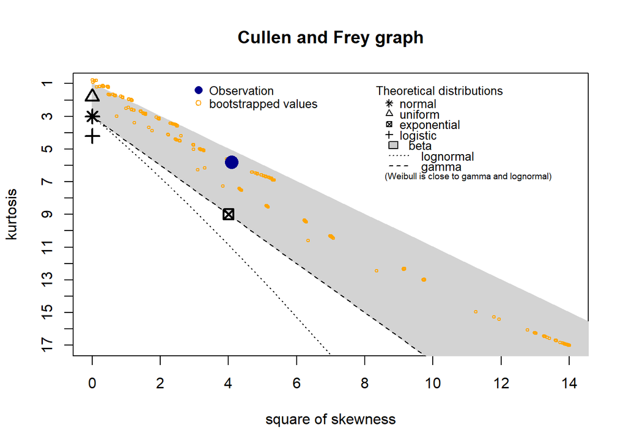

```
## summary statistics
## ------
## min:  0   max:  0.9314597
## median:  0.001771372
## mean:  0.154791
## estimated sd:  0.3240921
## estimated skewness:  2.021202
## estimated kurtosis:  5.796488
```

```r
Erem <- subset(dfREM, Genus == "Erwinia")
descdist(Erem$Abundance, boot = 1000)
```

```r
Erem.mod <- lm(logistic(Abundance) ~ success, data = Erem)
Anova(Erem.mod, type = "II")
```

```
## Anova Table (Type II tests)
##
## Response: logistic(Abundance)
##           Sum Sq Df F value Pr(>F)
## success    4.098  1  0.6406  0.439
## Residuals 76.756 12
```

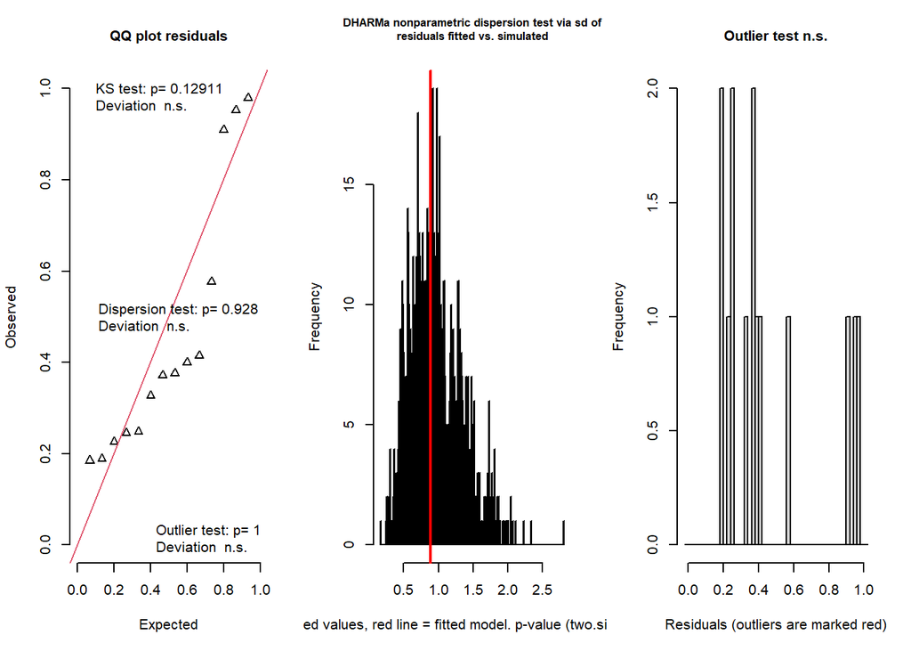

```
## $uniformity
##
##  One-sample Kolmogorov-Smirnov test
##
## data:  simulationOutput$scaledResiduals
## D = 0.30029, p-value = 0.1291
## alternative hypothesis: two-sided
##
##
## $dispersion
##
##  DHARMa nonparametric dispersion test via sd of residuals fitted vs.
##  simulated
##
## data:  simulationOutput
## dispersion = 0.92226, p-value = 0.928
## alternative hypothesis: two.sided
##
##
## $outliers
##
##  DHARMa outlier test based on exact binomial test with approximate
##  expectations
##
## data:  simulationOutput
## outliers at both margin(s) = 0, observations = 14, p-value = 1
## alternative hypothesis: true probability of success is not equal to 0.001998002
## 95 percent confidence interval:
##  0.0000000 0.2316358
## sample estimates:
## frequency of outliers (expected: 0.001998001998002 )
##                                                    0
```

```
## $uniformity
##
##  One-sample Kolmogorov-Smirnov test
##
## data:  simulationOutput$scaledResiduals
## D = 0.30029, p-value = 0.1291
## alternative hypothesis: two-sided
##
##
## $dispersion
##
##  DHARMa nonparametric dispersion test via sd of residuals fitted vs.
##  simulated
##
## data:  simulationOutput
## dispersion = 0.92226, p-value = 0.928
## alternative hypothesis: two.sided
##
##
## $outliers
##
##  DHARMa outlier test based on exact binomial test with approximate
##  expectations
##
## data:  simulationOutput
## outliers at both margin(s) = 0, observations = 14, p-value = 1
## alternative hypothesis: true probability of success is not equal to 0.001998002
## 95 percent confidence interval:
##  0.0000000 0.2316358
## sample estimates:
## frequency of outliers (expected: 0.001998001998002 )
##                                                    0
```

```r
res_Erem.mod <- simulateResiduals(Erem.mod, n = 1000)
testResiduals(res_Erem.mod)
```

# **References**

Davis NM, Proctor DiM, Holmes SP, Relman DA, Callahan BJ. 2018. Simple statistical identification and removal of contaminant sequences in marker-gene and metagenomics data. Microbiome. 6(1). doi:10.1186/S40168-018-0605-2.

Delignette-Muller ML, Dutang C. 2015. fitdistrplus: An R package for fitting distributions. J Stat Softw. 64(4):1–34. doi:10.18637/jss.v064.i04.

Dimitris Rizopoulos (2022). GLMMadaptive: Generalized Linear Mixed Models using Adaptive Gaussian Quadrature. R package version 0.8-5. https://CRAN.R-project.org/package=GLMMadaptive

Douglas Bates, Martin Maechler, Ben Bolker, Steve Walker (2015). Fitting Linear Mixed-Effects Models Using lme4. Journal of Statistical Software, 67(1), 1-48. doi:10.18637/jss.v067.i01.

John Fox and Sanford Weisberg (2019). An {R} Companion to Applied Regression, Third Edition. Thousand Oaks CA: Sage. URL: https://socialsciences.mcmaster.ca/jfox/Books/Companion/

Gavin L. Simpson (2022). permute: Functions for Generating Restricted Permutations of Data. R package version 0.9-7. https://CRAN.R-project.org/package=permute

Hartig F. 2021. DHARMa: Residual Diagnostics for Hierarchical (Multi-Level / Mixed) Regression Models. https://cran.r-project.org/package=DHARMa.

Højsgaard, Søren and Halekoh, Ulrich (2022). doBy: Groupwise Statistics, LSmeans, Linear Estimates, Utilities. R package version 4.6.12. https://CRAN.R-project.org/package=doBy

Kassambara, Alboukadel (2020). ggpubr: ‘ggplot2’ Based Publication Ready Plots. R package version 0.4.0. https://CRAN.R-project.org/package=ggpubr

Kuznetsova A, Brockhoff PB, Christensen RHB (2017). “lmerTest Package: Tests in Linear Mixed Effects Models.” *Journal of Statistical Software*, *82*(13), 1-26. doi: 10.18637/jss.v082.i13 (URL: https://doi.org/10.18637/jss.v082.i13).

Lahti, Leo et al. microbiome R package. URL: http://microbiome.github.io

Lüdecke D (2018). “ggeffects: Tidy Data Frames of Marginal Effects from Regression Models.” *Journal of Open Source Software*, *3*(26), 772. doi: 10.21105/joss.00772 (URL: https://doi.org/10.21105/joss.00772).

Lüdecke D (2021). *sjPlot: Data Visualization for Statistics in Social Science*. R package version 2.8.10, <URL: https://CRAN.R-project.org/package=sjPlot>.

Lüdecke D, Ben-Shachar MS, Patil I, Waggoner P, Makowski D. (2021) performance: An R Package for Assessment, Comparison and Testing of Statistical Models. Journal of Open Source Software, 6(60), 3139. doi:10.21105/joss.03139.

Lüdecke et al., (2021). see: An R Package for Visualizing Statistical Models. Journal of Open Source Software, 6(64), 3393. https://doi.org/10.21105/joss.03393

Mangiafico S. 2021. rcompanion: Functions to Support Extension Education Program Evaluation. https://cran.r-project.org/package=rcompanion.

Martinez Arbizu, Pedro (2017). pairwiseAdonis: Pairwise Multilevel Comparison using Adonis. R package version 0.4.

McMurdie PJ, Holmes S. 2013. Phyloseq: An R Package for Reproducible Interactive Analysis and Graphics of Microbiome Census Data. PLoS One. 8(4):e61217. doi:10.1371/journal.pone.0061217.

Mollie E. Brooks, Kasper Kristensen, Koen J. van Benthem, Arni Magnusson, Casper W. Berg, Anders Nielsen, Hans J. Skaug, Martin Maechler and Benjamin M. Bolker (2017). glmmTMB Balances Speed and Flexibility Among Packages for Zero-inflated Generalized Linear Mixed Modeling. The R Journal, 9(2), 378-400.

Oksanen J, Blanchet FG, Friendly M, Kindt R, Legendre P, McGlinn D, Minchin PR, O’Hara RB, Simpson GL, Solymos P, et al. 2020a. vegan: Community Ecology Package. https://cran.r-project.org/package=vegan.

Pedersen, Thomas Lin (2020). patchwork: The Composer of Plots. R package version 1.1.1. https://CRAN.R-project.org/package=patchwork

R Core Team. 2021. R: A language and environment for statistical computing. https://www.r-project.org/.

Russell V. Lenth (2022). emmeans: Estimated Marginal Means, aka Least-Squares Means. R package version 1.7.2. https://CRAN.R-project.org/package=emmeans

Sarkar, Deepayan (2008) Lattice: Multivariate Data Visualization with R. Springer, New York. ISBN 978-0-387-75968-5

Shetty, Sudarshan and Lahti, Leo (2021). microbiomeutilities: microbiomeutilities: Utilities for Microbiome Analytics. R package version 1.00.16.

Slowikowski, Kamil (2021). ggrepel: Automatically Position Non-Overlapping Text Labels with ‘ggplot2’. R package version 0.9.1. https://CRAN.R-project.org/package=ggrepel

Wickham H. 2016. ggplot2: Elegant Graphics for Data Analysis. New York: Springer-Verlag New York.

Wickham et al., (2019). Welcome to the tidyverse. Journal of Open Source Software, 4(43), 1686, https://doi.org/10.21105/joss.01686

Wickham H, Seidel D. 2020. scales: Scale Functions for Visualization. https://cran.r-project.org/package=scales.

Wickham H, François R, Henry L, Müller K. 2021. dplyr: A Grammar of Data Manipulation. https://cran.r-project.org/package=dplyr.

Hadley Wickham (2021). forcats: Tools for Working with Categorical Variables (Factors). R package version 0.5.1. https://CRAN.R-project.org/package=forcats

Wilke, Claus O. (2020). cowplot: Streamlined Plot Theme and Plot Annotations for ‘ggplot2’. R package version 1.1.1. https://CRAN.R-project.org/package=cowplot

Yihui Xie (2021). knitr: A General-Purpose Package for Dynamic Report Generation in R. R package version 1.37.